# MR V.S. 2sls (F30)

Author

Affiliation

Ruxin Shi

Michigan State University, Statistics and Probability

Published

2024-02-09 13:15:59 EST

Modified

2024-02-09 13:14:51 EST

# 1 Purpose

# 2 Simulation

This section provides the codes used to simulate the results.

## 2.1 Define Global Options

Global R chunk options are defined in the YAML header but local chunk options will over-ride global options. We can temporarily disable an individual chunk by inserting `#| eval = FALSE` on a line at the top of the chunk. The method for creating a `cfsize` option that controls font size in code chunks and their text output is based on an answer to a question posted on [stackoverflow.com](https://stackoverflow.com/a/46526740).

````markdown
```{r}
#| label: global-options
#| cfsize: footnotesize

# Create a custom chunk hook/option for controlling font size in chunk & output.
# Global value for this is set in YAML header.
def.chunk.hook  <- knitr::knit_hooks$get("chunk")
knitr::knit_hooks$set(chunk = function(x, options) {
  x <- def.chunk.hook(x, options)
  ifelse(options$cfsize != "normalsize",
         paste0("\n \\", options$cfsize,"\n\n", x, "\n\n \\normalsize"),
         x)
  })
```
````

## 2.2 Declare Path

This next chunk declares the path to this script relative to the project-level root directory. If the file is not in the right location under the project root you’ll get a warning message. This helps ensure relative paths are all working as expected.

````markdown
```{r}
#| label: declare-path

# Declare path to this script relative to the project root directory.
here::i_am(path = paste0(params$SourceDir, params$SourceFile))
```
````

[output not shown]

Note that `here()` creates a path relative to the location of the `EFNEPCBA.proj` file that will be portable across local repositories on different computers. That’s why we use that function when specifying file paths throughout the script.

## 2.3 Load Packages

Load R packages that we need to get additional functions.

````markdown
```{r}
#| label: load-packages

library(ivreg)
library(MASS)
library(ggplot2)
library(hdi)
```
```{r}
#| label: load-packages

library(glmnet)
```
```{r}
#| label: load-packages

library(dplyr)
```
```{r}
#| label: load-packages

library(qqman)
```
````

[output not shown]

[output not shown]

[output not shown]

````markdown
```{r}
#| label: load-packages

library(screening)
library(foreach)
library(doParallel)
```
```{r}
#| label: load-packages

library(kableExtra)
```
```{r}
#| label: load-packages

library(quarto)           # for quarto_version()
library(gridExtra)
```
```{r}
#| label: load-packages

library(ggpattern)
```
````

## 2.4 Setting

The chunk below shows the settings.

````markdown
```{r}
#| label: setting
#| eval: true
weightcal=function(weight){
  len=length(weight)
  a=(weight>=0)
  b=abs(weight)/sum(abs(weight))
  c=NULL
  for(i in 1:len){
    if(a[i])c[i]=b[i]
    if(!a[i])c[i]=-1*b[i]
  }
  return(c)
}
#Y outcome, D exposure
#Z instruments, X covariates
J=300#number of SNPs
J1=5 #useful SNPs
N=1000 #sample size
MAF=0.3 #minor allele frequency
Times=1000
sig=c(0.1,0.2)
squareh=c(0.15,0.3,0.5)
#pi=pi*c(1,-1,1,-1,1)
beta=c(-0.08,0,0.08) #causal effect
k=2
```
````

## 2.5 Simulation

The chunk below shows the simulation process of MR-SPLIT.

````markdown
```{r}
#| label: simulate_MR_SPLIT
#| eval: false
set.seed(1)
cl <- makeCluster(50)
registerDoParallel(cl)

#tt1=Sys.time()
for(ss in 1:2){
  for(jj in 1:3){
    for(hh in 1:3){
      results <- foreach(t=1:Times, .combine=rbind, .packages=c('ivreg','MASS','glmnet','screening')) %dopar% {
        G=matrix(0,nrow=N,ncol=J)
        for(i in 1:J){
          maf=MAF[i%%length(MAF)]
          if(i%%length(MAF)==0)maf=MAF[length(MAF)]
          GG1=runif(N,min=0,max=1)
          GG1[GG1<=(1-maf)^2]=0
          GG1[GG1>(1-maf^2)]=2
          GG1[which(GG1!=0&GG1!=2)]=1
          G[,i]=GG1
        }
        Sigma=matrix(c(1,sig[ss],sig[ss],1),nrow=2,ncol=2)
        sumsquarepi=squareh[hh]*Sigma[2,2]/(1-squareh[hh])/(2*MAF*(1-MAF))
        pi0=sqrt(sumsquarepi*c(0.4,0.4,0.1,0.05,0.05))
        error=mvrnorm(N,mu=c(0,0),Sigma=Sigma)
        #randomly choose SNPs that generates the esposure
        real=sample(c(1:J),size=J1,replace = FALSE)
        Greal=G[,real]
        #generate exposure
        X=as.matrix(Greal)%*%as.matrix(pi0)+error[,1]
        #generate outcome
        Y=X*beta[jj]+error[,2]


        #split sample
        selected=NULL
        unselected=1:N
        n=sample(unselected,size=N/k,replace = FALSE)
        selected=cbind(selected,n)
        for(p in 1:k){
          if(p<k){
            n=sample(unselected[-selected],size=N/k,replace = FALSE)
            selected=cbind(selected,n)
          }
        }
        #select IVs using SIS
        selectIV=list()
        for(p in 1:k){
          n=selected[,p]
          if(J<N/2){
            fit=screening(G[-n,],X[-n],method = "sis",num.select = 100)
          }
          if(J>N/2){
            fit=screening(G[-n,],X[-n],method = "sis")
          }
          selectIV[[p]]=fit$screen
        }
        #LASSO
        weights=list()
        for(p in 1:k){
          n=selected[,p]
          #select IVs
          lambda=cv.glmnet(G[-n,selectIV[[p]]],X[-n],alpha=1)$lambda.min
          lasso=glmnet(G[-n,selectIV[[p]]],X[-n],lambda=lambda)
          #coef of all IVs
          a=coef(lasso)[-1,]
          weights[[p]]=a[a!=0]
          #selected IVs
          selectIV[[p]]=selectIV[[p]][a!=0]
        }

        #select major and weak based on partial F statistics
        partialF=list()
        for(p in 1:k){
          n=selected[,p]
          full=lm(X[-n]~G[-n,selectIV[[p]]])
          Fs=NULL
          if(length(selectIV[[p]])==1){
            Fs=summary(lm(X[-n]~G[-n,selectIV[[p]]]))$fstat[1]
          }
          if(length(selectIV[[p]])>1){
            for(q in 1:length(selectIV[[p]])){
              reduced=lm(X[-n]~G[-n,selectIV[[p]][-q]])
              Fs[q]=anova(reduced,full)$F[2]
            }
          }
          partialF[[p]]=Fs
        }

        selectmajorF30=list()
        selectweakF30=list()

        for(p in 1:k){
          selectmajorF30[[p]]=selectIV[[p]][partialF[[p]]>=30]
          selectweakF30[[p]]=selectIV[[p]][partialF[[p]]<30]

        }

        #Get coef1
        combineMajor1=list()
        for(p in 1:k){
          n=selected[,p]
          weakwei1=weights[[p]][partialF[[p]]<30]
          if(length(weakwei1)>1){
            weakwei1=weightcal(weakwei1)
            combineMajor1[[p]]=cbind(G[n,selectmajorF30[[p]]],G[n,selectweakF30[[p]]]%*%weakwei1)
          }
          if(length(weakwei1)<=1) combineMajor1[[p]]=G[n,selectIV[[p]]]
        }

        #MAJOR1
        hatX=NULL
        for(p in 1:k){
          n=selected[,p]
          fit=lm(X[n]~combineMajor1[[p]])
          hatX=c(hatX,fit$fitted.values)
        }
        fit2=lm(Y[c(selected)]~hatX)
        Major.all=c(summary(fit2)$coef[2,1:4])
        return(Major.all)
      }
      write.table(results,file=paste0("2SLS/results/F30_sumresultMR_ss",ss,"_jj",jj,"_hh",hh,".txt"))
    }
  }
}

stopCluster(cl)
```
````

The chunk below shows the simulation process of 2SLS and LIML.

````markdown
```{r}
#| label: simulate_2SLS_LIML
#| eval: false
k=2
set.seed(1)
cl <- makeCluster(10)
registerDoParallel(cl)

for(ss in 1:2){
  for(jj in 1:3){
    for(hh in 1:3){
results <- foreach(t=1:Times, .combine=rbind, .packages=c('ivreg','MASS','glmnet','screening','ivmodel')) %dopar% {
  #generate SNPs
  G=matrix(0,nrow=N,ncol=J)
  for(i in 1:J){
    maf=MAF[i%%length(MAF)]
    if(i%%length(MAF)==0)maf=MAF[length(MAF)]
    GG1=runif(N,min=0,max=1)
    GG1[GG1<=(1-maf)^2]=0
    GG1[GG1>(1-maf^2)]=2
    GG1[which(GG1!=0&GG1!=2)]=1
    G[,i]=GG1
  }
  Sigma=matrix(c(1,sig[ss],sig[ss],1),nrow=2,ncol=2)
  sumsquarepi=squareh[hh]*Sigma[2,2]/(1-squareh[hh])/(2*MAF*(1-MAF))
  pi0=sqrt(sumsquarepi*c(0.4,0.4,0.1,0.05,0.05))
  error=mvrnorm(N,mu=c(0,0),Sigma=Sigma)
  #randomly choose SNPs that generates the esposure
  real=sample(c(1:J),size=J1,replace = FALSE)
  Greal=G[,real]
  #generate exposure
  X=as.matrix(Greal)%*%as.matrix(pi0)+error[,1]
  #generate outcome
  Y=X*beta[jj]+error[,2]

  #TSLS and LIML
        #split sample
        selected=NULL
        unselected=1:N
        n=sample(unselected,size=N/k,replace = FALSE)
        selected=cbind(selected,n)
        for(p in 1:k){
          if(p<k){
            n=sample(unselected[-selected],size=N/k,replace = FALSE)
            selected=cbind(selected,n)
          }
        }

  #select IVs using SIS
  n=selected[,1]#used to estimate
  selectIV=NULL
  if(J<N/2){
    fit=screening(G[-n,],X[-n],method = "sis",num.select = 100)
  }
  if(J>N/2){
    fit=screening(G[-n,],X[-n],method = "sis")
  }
  selectIV=fit$screen
  #LASSO
  #select IVs
  lambda=cv.glmnet(G[-n,selectIV],X[-n],alpha=1)$lambda.min
  lasso=glmnet(G[-n,selectIV],X[-n],lambda=lambda)
  #coef of all IVs
  a=coef(lasso)[-1,]
  #selected IVs
  selectIV=selectIV[a!=0]
  SNP=G[n,selectIV]
  fit1=ivmodel(Y=Y[n],D=X[n],Z=SNP)
  point.est1=c(fit1$kClass$point.est[2],fit1$kClass$std.err[2],fit1$kClass$test.stat[2],fit1$kClass$p.value[2])
  point.est3=c(fit1$LIML$point.est,fit1$LIML$std.err,fit1$LIML$test.stat,fit1$LIML$p.value)
  return(rbind(point.est1,point.est3))
}
      sumresult=list("TSLS"=results[c(seq(1,Times*2,by=2)),],"LIML"=results[c(seq(2,Times*2,by=2)),])
write.table(sumresult,file=paste0("results/2SLS/sumresult_2sls_ss",ss,"hh_",hh,"jj_",jj,"_.txt"))
    }
  }
}
stopCluster(cl)
```
````

# 3 Results

## 3.1 Boxplots of Estimates

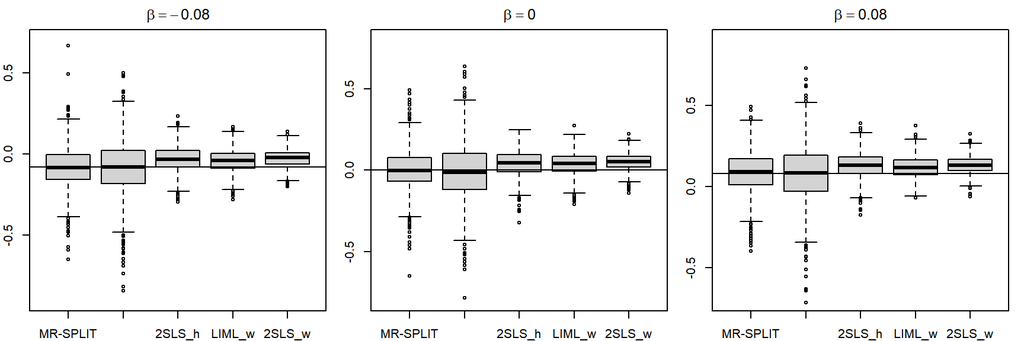

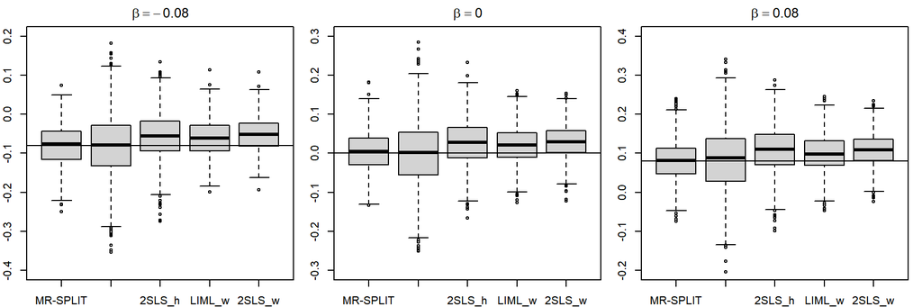

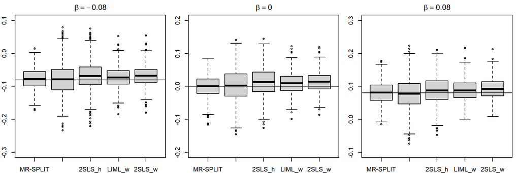

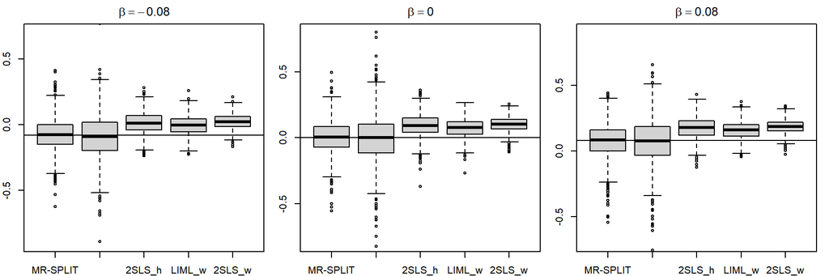

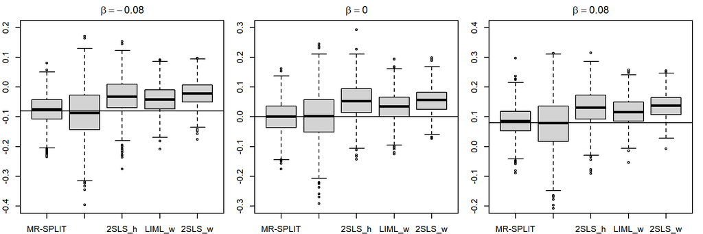

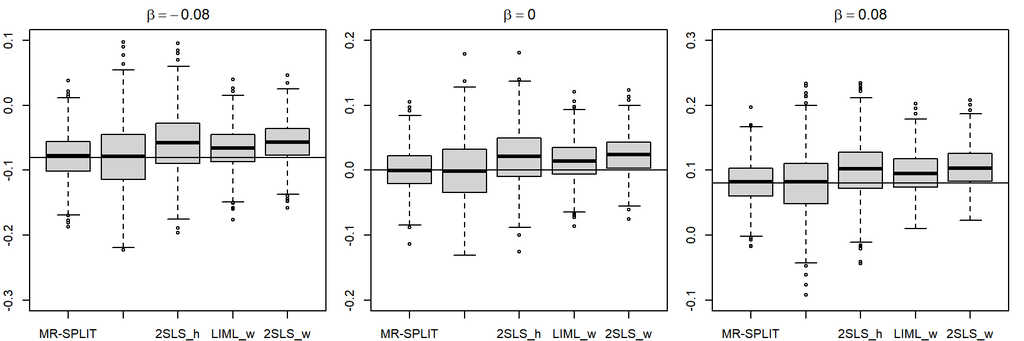

````markdown
```{r fig.width=9, fig.height=3}
setwd("C:/Users/shirx/OneDrive/Desktop/Major/Simulation study")
for(ss in 1:2){
  for(hh in 1:3){
    par(mfrow=c(1,3),mar=c(2,2,2,1))
    for(jj in 1:3){
      file=paste0("results/2SLS/sumresult_2sls_ss",ss,"hh_",hh,"jj_",jj,"_.txt")
      data1=read.table(file = file,header = TRUE)
      file=paste0("results/2SLS/F30_sumresultMR_ss",ss,"_jj",jj,"_hh",hh,".txt")
      data2=read.table(file = file,header = TRUE)
       file=paste0("results/2SLS/whole_sumresult_2sls_ss",ss,"hh_",hh,"jj_",jj,"_.txt")
      data3=read.table(file = file,header = TRUE)
      if(hh==1){
        a=c(-0.8,0.8)
      }
      if(hh==2){
        a=c(-0.3,0.3)
      }
      if(hh==3){
        a=c(-0.2,0.2)
      }
      if(jj==1){
        a=a-0.1
        boxplot(data.frame("MR-SPLIT"=data2[,1],"LIML_h"=data1[,5],"2SLS_h"=data1[,1],"LIML_w"=data3[,5],"2SLS_w"=data3[,1],check.names = FALSE),main=expression(beta == -0.08),ylim=a)
      }
      if(jj==2){
        boxplot(data.frame("MR-SPLIT"=data2[,1],"LIML_h"=data1[,5],"2SLS_h"=data1[,1],"LIML_w"=data3[,5],"2SLS_w"=data3[,1],check.names = FALSE),main=expression(beta == 0),ylim=a)
      }
       if(jj==3){
         a=a+0.1
        boxplot(data.frame("MR-SPLIT"=data2[,1],"LIML_h"=data1[,5],"2SLS_h"=data1[,1],"LIML_w"=data3[,5],"2SLS_w"=data3[,1],check.names = FALSE),main=expression(beta == 0.08),ylim=a)
      }
      abline(h=beta[jj],col="black")
    }
  }
}
```
````